# Hospital Locations

Raameen Ahmed, Zain Ahmed, Mustafa Nasir

2025-08-23

# 911 Calls Analysis

**Inquiry:** Is there a statistical spatial correlation between the 911 call density ( from 2018-2025 ) and proximity to hospitals in Wayne County, MI?

**Null Hypothesis:** There is no statistically significant spacial correlation between hospital locations and 911 call density

**Hypothesis 1:** There is a positive statistical significanct spacial correlation between 911 call density and hospital locations

What this **means:** The higher the 911 call density, the more likely there is to have a hospital nearby

**Disclaimer:** Healthcare locations vary based on a large set of factors such as environment, demand, population, proximity, competition, government policies, and costs as in other hospital ranking problems as stated in the article *Hospital Location Selection: A Systematic Literature Review on Methodologies and Applications*.

The research aims to focus on the demand sector and blueprinting the trends and correlations of hospital locations based on 911 calls in the Wayne County, MI, area. Essentially, the data should statistically forecast areas in which hospitals would be beneficial to the public based on factors such as demand, proximity, and population.

# Top 10 Most Dangerous Locations

## In Relation To Top 4 Shooting Locations

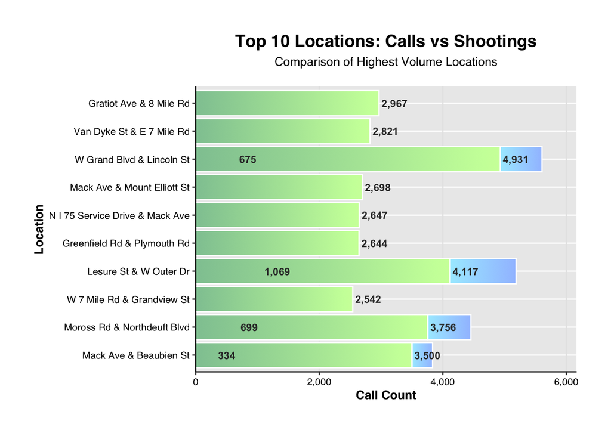

The graph illustrates the relationship between 911 calls and highlights significant hotspot locations. Four major intersections can be listed as the most “dangerous” due to their volume of calls and volume of shooting related calls.

**Leisure St & W Outer Dr** has records of **5000+** calls, with **1000+** of them being related to shootings, marking it the most dangerous of them all. **Grand Blvd & Lincoln St** does also have **5000+** calls, however **Moross Rd & Northdeuft Blvd** takes the second place because it has **699** shooting calls. **Mac Ave & Beaubien St** is the safest street out of these four locations with an outstanding number of **334** shooting related calls.

# Hospital Placements Geolocated

### 911 Call Hotspots in Relation to Hospital Locations

[interactive chart not shown]

### Shooting Hotspots in Relation to Hospital Locations

[interactive chart not shown]

Both maps indicate similar prospects: **there is a potential correlation between hospital locations and 911 call hotspots-specifically** *shooting hotspots.*

**W Grand Blvd & Lincoln St**, **Lesure St & W Outer Dr**, **Moross Rd & Northdeuft Blvd**, and **Mack Ave & Beaubien St** are prominent locations which home various hospitals due to sheer demand and efficient government spending. We can also see locations such as **Warwick St & Plymouth Rd** with **98** shooting distress calls and **Chapel St & W McNichols Rd** with **108** shooting distress calls, but no prominent hospital locations nearby. This may be due to other underlying factors such as environment, population, government policies, and costs.

Demand, however, is highly prominent in this areas due to their volume of 911 shooting calls. Although the density is not as high as those in the top 4 shooting locations, a hospital in between these two areas that include HVIPs could reduce crime rates as a whole. The Caught in the Crossfire program, one of the first program to use HVIPs, found that its participants were “70 percent less likely to be arrested and 60 percent less likely to have criminal involvement than a control group. Additionally, the study revealed that the program saved hospitals up to $1.5 million annually,” (Healing-Communities-In-Chrisis). For the Wayne County community, it could lower the average crime rate exponentially by giving young ones exposure to resourceful educational programs, breaking generational high crime rates, while simultaneously saving millions in government funding.

# Proposal for More Funding Towards Programs For Wayne County

Summary Statistics for 911 Calls (2018-2024)

| year | shots_fired | assault_battery |
| --- | --- | --- |
| 2025 | 1333 | 4550 |
| 2024 | 4466 | 13509 |
| 2023 | 5890 | 13976 |
| 2022 | 6872 | 12832 |
| 2021 | 8042 | 12958 |
| 2020 | 10569 | 14273 |
| 2019 | 6917 | 14365 |
| 2018 | 6512 | 2261 |

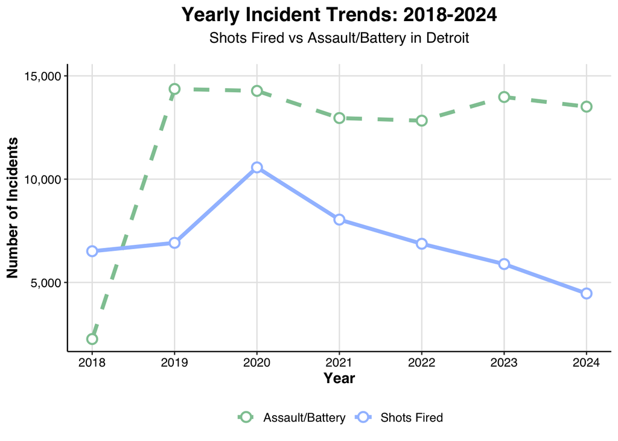

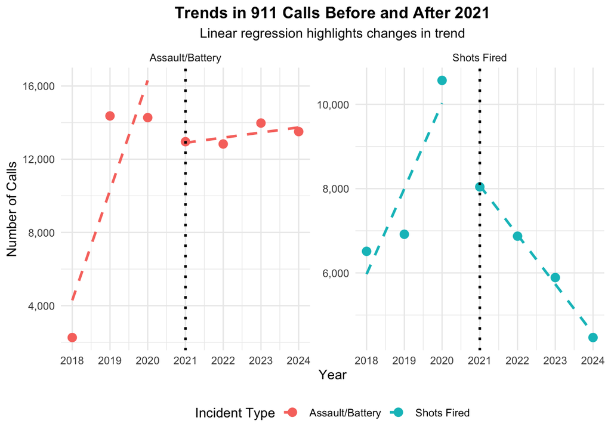

Trend Analysis of Incident Types

| Metric | Change Since 2021 | Total Change (2018-2024) |
| --- | --- | --- |
| Shots Fired | ▼ 44.5% | ▼ 31.4% |
| Assault/Battery | ▲ 4.3% | ▲ 497.5% |

Legend: ▼ = Decrease, ▲ = Increase  
Shots Fired has seen decreases while Assault/Battery has increased significantly

In 2021, Gretchen Whitmer proposed $30 million dollars in funding to programs such as HVIPs, Mental Health, Substance Abuse and Sexual Assault Services, Wraparound Services for High-Risk Youth and Young Adults, and others. The proposal claimed to “reduce violence by providing grant recipients with access to technical assistance and training, evaluation support, and coordination,” (Michigan.gov).

While the existing programs have been successful in reducing gun violence, new funding and strategies should be adapted to address other forms of violence, like assault and battery.

# References

### **Datasets**

- **Detroit Open Portal:** Provided substantial data regarding 911 calls and locations
  - 2018: https://data.detroitmi.gov/datasets/e9243485b5254b4d9e177bc1a9e0eed4_0/explore?location=42.204235%2C-83.335395%2C8.42&showTable=true
  - 2019: https://data.detroitmi.gov/datasets/b480271e68094289905a9b07e470b2d1_0/explore?location=42.204235%2C-83.335395%2C8.42&showTable=true
  - 2020: https://data.detroitmi.gov/datasets/7f32a6176ca14eb3b1c43241fdc953ca_0/explore?location=42.204235%2C-83.335395%2C8.42&showTable=true
  - 2021: https://data.detroitmi.gov/datasets/bb279dd59fa9414a97185e1a2d2db200_0/explore?showTable=true
  - 2022: https://data.detroitmi.gov/datasets/23bef6250e904113be5954807c91e739_0/explore?showTable=true
  - 2023: https://data.detroitmi.gov/datasets/13fb64ee36524809bd9a4a03e30151a2_0/explore?showTable=true
  - 2024: https://data.detroitmi.gov/datasets/cb16e22c60644a68b1eca5a6c3d67088_0/explore?showTable=true
  - 2025: http://data.detroitmi.gov/datasets/a1c24156ffe146b4964ed128c5e1f12f_0/explore?showTable=true
- **United States Census Bureau:** Provided five year population estimates
  - 2018-2022: https://data.census.gov/table/ACSDP5Y2022.DP05?q=population+of+wayne+county+michigan+DP05&t=Populations+and+People
  - 2019-2023: https://data.census.gov/table/ACSDP5Y2023.DP05?q=population+of+wayne+county+michigan+DP05&t=Populations+and+People

### **Literature**

- **Wiley Online Library:** Provided information regarding hospital location urban planning
  - https://onlinelibrary.wiley.com/doi/10.1155/2021/6682958#:~:text=This%20problem%20depends%20on%20many,problems%20%5B4%E2%80%938%5D.
- https://www.michigan.gov/whitmer/news/press-releases/2021/11/02/governor-whitmer-proposes-30-million-investment-to-fund-violence-prevention-and-reduction-initiativ
- https://www.uppermichiganssource.com/2024/02/07/gov-whitmer-discuss-2025-michigan-state-budget/

## Other Stats

### Top 50 mean median standard deviation table

Summary Statistics for Top 50 Locations

| Statistic | Value |
| --- | --- |
| Mean | 2273.9000 |
| Median | 2113.5000 |
| Standard Deviation | 650.1172 |

### Top 10 mean median standard deviation table

Summary Statistics for Top 10 Locations

| Statistic | Value |
| --- | --- |
| Mean | 3271.9000 |
| Median | 2894.0000 |
| Standard Deviation | 786.3709 |